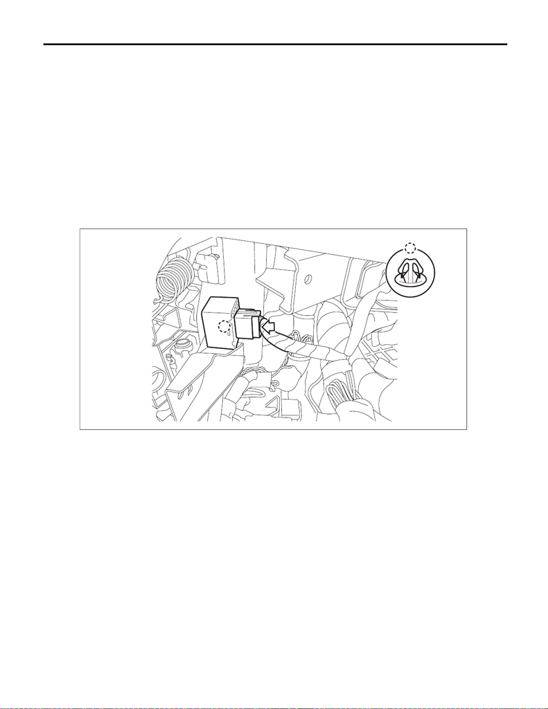

LI-33

Turn Signal Light & Hazard Light Module

LIGHTING SYSTEM

17.Turn Signal Light & Hazard Light Module

A: REMOVAL

CAUTION:

Before handling the airbag module, refer to “CAUTION” of “General Description” in “AIRBAG SYS-

TEM”. <Ref. to AB-9, CAUTION, General Description.>

1) Disconnect the battery ground cable and wait for at least 60 seconds before starting work. <Ref. to NT-5,

BATTERY, NOTE, Note.>

NOTE:

For models other than STI model, disconnect the ground terminal from battery sensor.

2) Remove the instrument panel lower cover. <Ref. to EI-61, REMOVAL, Instrument Panel Lower Cover.>

3) Remove the knee airbag module. <Ref. to AB-35, REMOVAL, Knee Airbag Module.>

4) Remove the turn signal and hazard module.

(1) Disconnect the connector.

(2) Release the claws, and then remove the turn signal & hazard module.

B: INSTALLATION

CAUTION:

Before handling the airbag module, refer to “CAUTION” of “General Description” in “AIRBAG SYS-

TEM”. <Ref. to AB-9, CAUTION, General Description.>

1) Install the turn signal & hazard module.

2) Install the knee airbag module.

Tightening torque:

7.5 N·m (0.8 kgf-m, 5.5 ft-lb)

3) Install the instrument panel lower cover.

4) Connect the battery ground terminal. <Ref. to NT-5, BATTERY, NOTE, Note.>

NOTE:

For models other than STI model, connect the ground terminal to battery sensor.

LI-01203

[figure not shown]

LI-34

Turn Signal Light & Hazard Light Module

LIGHTING SYSTEM

C: INSPECTION

1) Measure the voltage between connector terminal and chassis ground.

Preparation tool:

Circuit tester

Repair or replace the harness if the inspection result is not within the standard value.

2) Measure the resistance between connector terminal and chassis ground.

Repair or replace the harness if the inspection result is not within the standard value.

3) Connect the connector.

4) Measure the voltage between connector terminal and chassis ground.

Replace the turn signal and hazard module if the inspection result is not within the standard value.

LI-01720

1 2 3

4 5 6 7 8

Terminal No. Inspection conditions Standard

4 (+) — Chassis ground (–) Always 10 — 14 V

1 (+) — Chassis ground (–) IG OFF → ON Less than 1 V → 10 — 14 V

Terminal No. Inspection conditions Standard

7 — Chassis ground Always Less than 1 Ω

Terminal No.

Input/

Output

Inspection conditions Standard

6 (+) — Chassis ground (–) Input Turn signal switch (right) OFF → ON 9 V or more → less than 1 V

5 (+) — Chassis ground (–) Input Turn signal switch (left) OFF → ON 9 V or more → less than 1 V

8 (+) — Chassis ground (–) Input Hazard switch OFF → ON 9 V or more → less than 1 V

2 (+) — Chassis ground (–) Output Turn signal switch (right) OFF → ON

Repeat less than 1 V → less than 1 V ←→

more than 9 V at 60 to 120 times per minute.

3 (+) — Chassis ground (–) Output Turn signal switch (left) OFF → ON

Repeat less than 1 V → less than 1 V ←→

more than 9 V at 60 to 120 times per minute.

2 (+) — Chassis ground (–) Output Hazard switch OFF → ON

Repeat less than 1 V → less than 1 V ←→

more than 9 V at 60 to 120 times per minute.

3 (+) — Chassis ground (–) Output Hazard switch OFF → ON

Repeat less than 1 V → less than 1 V ←→

more than 9 V at 60 to 120 times per minute.